# Using Clustering To Analyze HealthCare Data

- Motivation:

In the last assigment we worked with a Health Care dataset that inlcuded values of several providers on different states in the US. The dataset also included average charges, total payments and medicare payments per porivder id. In order to analyze the data I used several feature engineering techniques to aggregate data and create several new variables that identified unsual behavior. The new variable created include:

'charge_vs_medic', 'Bining', 'perc_0.0_11.0', 'perc_11.0_22.0', 'perc_22.0_33.0', 'perc_33.0_44.0', 'perc_44.0_56.0', 'perc_56.0_67.0', 'perc_67.0_78.0', 'perc_78.0_89.0', 'perc_89.0_100.0', 'RANK', 'Cluster', 'Flag_Medicare', 'Flag_Rank', 'Flag_Cluster'

- Resources:

  ```
    *Modified Dataset on HealthCare costs provided by the CMS.
    *Data Visualizations with Matplotlib
    *Clustering Analysis
  ```

- Methods:

- Objective:

By using the already modified dataset on HealthCare Data create clusters of data based on all the variables provided and provide some insights into the clusters.

```python
import os
import pandas as pd
import matplotlib.pyplot as plt
import plotly.graph_objects as go
import plotly.io as pio
from sklearn.cluster import KMeans
from sklearn.manifold import TSNE
import seaborn as sns
import numpy as np
from sklearn.preprocessing import LabelBinarizer,normalize,StandardScaler
from math import isnan
from sklearn.discriminant_analysis import LinearDiscriminantAnalysis as LDA
os.chdir("/Users/luislosada/Columbia Drive/Anomaly Detection/Module 5")
```

```python
data = pd.read_csv('HealthCareData_FE_V1.csv',index_col = 0)
```

```python
#Looking at all variables available.
list(data.columns)
```

```
['DRG Definition',
 'Provider Id',
 'Provider Name',
 'Provider Street Address',
 'Provider City',
 'Provider State',
 'Provider Zip Code',
 'Total Discharges',
 'Average Covered Charges',
 'Average Total Payments',
 'Average Medicare Payments',
 'charge_vs_medic',
 'Bining',
 'perc_0.0_11.0',
 'perc_11.0_22.0',
 'perc_22.0_33.0',
 'perc_33.0_44.0',
 'perc_44.0_56.0',
 'perc_56.0_67.0',
 'perc_67.0_78.0',
 'perc_78.0_89.0',
 'perc_89.0_100.0',
 'RANK',
 'Cluster',
 'Flag_Medicare',
 'Flag_Rank',
 'Flag_Cluster']
```

Before I start I'll create a function to group by columns and provide statistics within those groups in a dataframe format. This I will use throughout the walkthrough to aggregate data and extract statistics.

```python
#Lets see the stats of the continuous variables
def stat_flat(data,group_var1,cont_var,group_var2=False):
    if group_var2 == False:
        coln =list(data[[group_var1,cont_var]].describe().index)
        row = data[[group_var1]].drop_duplicates().reset_index(drop=True).values.tolist()
        row = [item for sublist in row for item in sublist] #faltten the list
        desc_cont_var = pd.DataFrame(data[[group_var1,cont_var]].groupby(group_var1).describe().values.tolist(), columns=coln,index=row)
    elif group_var2 != False:
        coln =list(data[[group_var1,group_var2,cont_var]].describe().index)
        row = data[[group_var1,group_var2]].drop_duplicates().reset_index(drop=True).values.tolist()
        row_s = [sublist[0] for sublist in row] #faltten the list
        row2= pd.DataFrame([sublist[1] for sublist in row])
        desc_cont_var = pd.DataFrame(data[[group_var1,group_var2,cont_var]].groupby([group_var1,group_var2]).describe().values.tolist(), columns=coln,index=row_s,)
        row2 =row2.set_index(desc_cont_var.index)
        desc_cont_var.insert(loc=0,column=str(group_var2),value=row2)
    return desc_cont_var
stat_flat(data,"DRG Definition","Average Covered Charges",'Provider State').head(n=10)
```

|  | Provider State | count | mean | std | min | 25% | 50% | 75% | max |
| --- | --- | --- | --- | --- | --- | --- | --- | --- | --- |
| 001 - HEART TRANSPLANT OR IMPLANT OF HEART ASSIST SYSTEM W MCC | AL | 1.0 | 1.014783e+06 | NaN | 1014783.45 | 1.014783e+06 | 1014783.450 | 1.014783e+06 | 1014783.45 |
| 001 - HEART TRANSPLANT OR IMPLANT OF HEART ASSIST SYSTEM W MCC | AZ | 1.0 | 3.820510e+05 | NaN | 382051.00 | 3.820510e+05 | 382051.000 | 3.820510e+05 | 382051.00 |
| 001 - HEART TRANSPLANT OR IMPLANT OF HEART ASSIST SYSTEM W MCC | CA | 7.0 | 1.727046e+06 | 606230.383921 | 971881.48 | 1.460466e+06 | 1517857.610 | 1.969748e+06 | 2739156.06 |
| 001 - HEART TRANSPLANT OR IMPLANT OF HEART ASSIST SYSTEM W MCC | CO | 1.0 | 1.017809e+06 | NaN | 1017809.00 | 1.017809e+06 | 1017809.000 | 1.017809e+06 | 1017809.00 |
| 001 - HEART TRANSPLANT OR IMPLANT OF HEART ASSIST SYSTEM W MCC | CT | 2.0 | 8.498158e+05 | 588792.861386 | 433476.38 | 6.416461e+05 | 849815.805 | 1.057986e+06 | 1266155.23 |
| 001 - HEART TRANSPLANT OR IMPLANT OF HEART ASSIST SYSTEM W MCC | DC | 1.0 | 8.805949e+05 | NaN | 880594.90 | 8.805949e+05 | 880594.900 | 8.805949e+05 | 880594.90 |
| 001 - HEART TRANSPLANT OR IMPLANT OF HEART ASSIST SYSTEM W MCC | FL | 3.0 | 8.594181e+05 | 298220.589730 | 519927.31 | 7.495705e+05 | 979213.600 | 1.029164e+06 | 1079113.53 |
| 001 - HEART TRANSPLANT OR IMPLANT OF HEART ASSIST SYSTEM W MCC | GA | 2.0 | 7.324464e+05 | 268855.624155 | 542336.73 | 6.373915e+05 | 732446.365 | 8.275012e+05 | 922556.00 |
| 001 - HEART TRANSPLANT OR IMPLANT OF HEART ASSIST SYSTEM W MCC | IL | 1.0 | 7.604122e+05 | NaN | 760412.21 | 7.604122e+05 | 760412.210 | 7.604122e+05 | 760412.21 |
| 001 - HEART TRANSPLANT OR IMPLANT OF HEART ASSIST SYSTEM W MCC | IN | 4.0 | 9.844441e+05 | 294141.658749 | 690122.53 | 8.351249e+05 | 929942.825 | 1.079262e+06 | 1387768.41 |

First lets aggregate by Provider State and DRG code.

```python
DF = data.groupby(["DRG Definition",'Provider State']).size().reset_index()

mean_total_discharges = stat_flat(data,"DRG Definition","Total Discharges",'Provider State')['mean']
mean_average_covered_charges = stat_flat(data,"DRG Definition","Average Covered Charges",'Provider State')['mean']
mean_average_total_payments    = stat_flat(data,"DRG Definition",'Average Total Payments','Provider State')['mean']
mean_average_medicare_payments = stat_flat(data,"DRG Definition",'Average Medicare Payments','Provider State')['mean']
mean_average_charge_vs_medic = stat_flat(data,"DRG Definition",'charge_vs_medic','Provider State')['mean']
```

Next lets create a dataframe with all this aggregated data.

```python
Mean_DF = {"Provider State":list(DF["Provider State"]),
           "mean_total_discharges":mean_average_total_payments,
           "mean_average_covered_charges":mean_average_covered_charges,
           "mean_average_total_payments":mean_average_total_payments,
           "mean_average_medicare_payments":mean_average_medicare_payments,
           "mean_charge_vs_medic":mean_average_charge_vs_medic}

Mean_DF = pd.DataFrame.from_dict(Mean_DF)
Mean_DF.reset_index(level=0, inplace=True)
Mean_DF.rename(columns={"index": "DRG Definition"},inplace=True)
Mean_DF.head()
```

|  | DRG Definition | Provider State | mean_total_discharges | mean_average_covered_charges | mean_average_total_payments | mean_average_medicare_payments | mean_charge_vs_medic |
| --- | --- | --- | --- | --- | --- | --- | --- |
| 0 | 001 - HEART TRANSPLANT OR IMPLANT OF HEART ASS... | AL | 171081.180000 | 1014783.450 | 171081.180000 | 141193.910000 | 13.910000 |
| 1 | 001 - HEART TRANSPLANT OR IMPLANT OF HEART ASS... | AZ | 194081.390000 | 382051.000 | 194081.390000 | 167511.960000 | 43.850000 |
| 2 | 001 - HEART TRANSPLANT OR IMPLANT OF HEART ASS... | CA | 362790.944286 | 1727046.170 | 362790.944286 | 336733.212857 | 21.087143 |
| 3 | 001 - HEART TRANSPLANT OR IMPLANT OF HEART ASS... | CO | 225019.730000 | 1017809.000 | 225019.730000 | 209039.640000 | 20.540000 |
| 4 | 001 - HEART TRANSPLANT OR IMPLANT OF HEART ASS... | CT | 285937.460000 | 849815.805 | 285937.460000 | 211559.700000 | 30.830000 |

By joining the mean aggregated data to the bigger set I can now create a ratio where each observation is compared to its corresponding aggregated mean data.

```python
Total_DF = pd.merge(data,
         Mean_DF,
         on=["DRG Definition","Provider State"]
            )

Total_DF['ratio_Average_Covered_Charges'] = Total_DF['Average Covered Charges']/Total_DF['mean_average_covered_charges']
Total_DF['ratio_Total_Payments'] = Total_DF['Average Total Payments']/Total_DF['mean_average_total_payments']
Total_DF['ratio_Medicare_Payments'] = Total_DF['Average Medicare Payments']/Total_DF['mean_average_medicare_payments']
Total_DF['ratio_Total_Discharges'] = Total_DF['Total Discharges']/Total_DF['mean_total_discharges']
Total_DF['ratio_charge_vs_medic'] = Total_DF['charge_vs_medic']/Total_DF['mean_charge_vs_medic']


Total_DF.head()
```

|  | DRG Definition | Provider Id | Provider Name | Provider Street Address | Provider City | Provider State | Provider Zip Code | Total Discharges | Average Covered Charges | Average Total Payments | ... | mean_total_discharges | mean_average_covered_charges | mean_average_total_payments | mean_average_medicare_payments | mean_charge_vs_medic | ratio_Average_Covered_Charges | ratio_Total_Payments | ratio_Medicare_Payments | ratio_Total_Discharges | ratio_charge_vs_medic |
| --- | --- | --- | --- | --- | --- | --- | --- | --- | --- | --- | --- | --- | --- | --- | --- | --- | --- | --- | --- | --- | --- |
| 0 | 001 - HEART TRANSPLANT OR IMPLANT OF HEART ASS... | 10033 | UNIVERSITY OF ALABAMA HOSPITAL | 619 SOUTH 19TH STREET | BIRMINGHAM | AL | 35233 | 11 | 1014783.45 | 171081.18 | ... | 171081.180000 | 1014783.45 | 171081.180000 | 141193.910000 | 13.910000 | 1.000000 | 1.000000 | 1.000000 | 0.000064 | 1.000000 |
| 1 | 001 - HEART TRANSPLANT OR IMPLANT OF HEART ASS... | 30103 | MAYO CLINIC HOSPITAL | 5777 EAST MAYO BOULEVARD | PHOENIX | AZ | 85054 | 28 | 382051.00 | 194081.39 | ... | 194081.390000 | 382051.00 | 194081.390000 | 167511.960000 | 43.850000 | 1.000000 | 1.000000 | 1.000000 | 0.000144 | 1.000000 |
| 2 | 001 - HEART TRANSPLANT OR IMPLANT OF HEART ASS... | 50025 | UNIVERSITY OF CALIFORNIA SAN DIEGO MEDICAL CENTER | 200 WEST ARBOR DRIVE | SAN DIEGO | CA | 92103 | 21 | 971881.48 | 324050.71 | ... | 362790.944286 | 1727046.17 | 362790.944286 | 336733.212857 | 21.087143 | 0.562742 | 0.893216 | 0.874341 | 0.000058 | 1.436420 |
| 3 | 001 - HEART TRANSPLANT OR IMPLANT OF HEART ASS... | 50100 | SHARP MEMORIAL HOSPITAL | 7901 FROST ST | SAN DIEGO | CA | 92123 | 18 | 1517857.61 | 257177.33 | ... | 362790.944286 | 1727046.17 | 362790.944286 | 336733.212857 | 21.087143 | 0.878875 | 0.708886 | 0.693525 | 0.000050 | 0.729829 |
| 4 | 001 - HEART TRANSPLANT OR IMPLANT OF HEART ASS... | 50108 | SUTTER MEDICAL CENTER, SACRAMENTO | 2825 CAPITOL AVENUE | SACRAMENTO | CA | 95816 | 17 | 1470341.06 | 346150.12 | ... | 362790.944286 | 1727046.17 | 362790.944286 | 336733.212857 | 21.087143 | 0.851362 | 0.954131 | 1.005164 | 0.000047 | 1.091660 |

5 rows × 37 columns

Once this is done we can move on to creating a subset of the data aggregated by provider ID. I will use the newly created data to create clusters of providers.

```python
#Group by Provider and get count of discharges, and mean of all three main vars

for_analysis = pd.DataFrame({"Total_Discharges":stat_flat(Total_DF,"Provider Id","ratio_Total_Discharges")['mean'],
              "Mean_Covered_Charges":stat_flat(Total_DF,"Provider Id","ratio_Average_Covered_Charges")['mean'],
              "Mean_Total_Payments":stat_flat(Total_DF,"Provider Id","ratio_Total_Payments")['mean'],
              "Mean_Medicare_Payments":stat_flat(Total_DF,"Provider Id","ratio_Medicare_Payments")['mean'],
              "Mean_Charge_vs_Medic":stat_flat(Total_DF,"Provider Id","ratio_charge_vs_medic")['mean']})


for_analysis.head(10)
```

[output not shown]

### K-Means Clustering

The method picked for clustering these observations is K-Means clustering. This method works to sepprate observations into specific clusters based on the characteristics of their variables. In each iteration of the algorithm observations are relocated to different clusters and a cluster centroid is created. The goal of the algorithm is to create centroids that have a total sum of means within each cluster as small as possible and a total sum of means from cluster to cluster as large as possible.

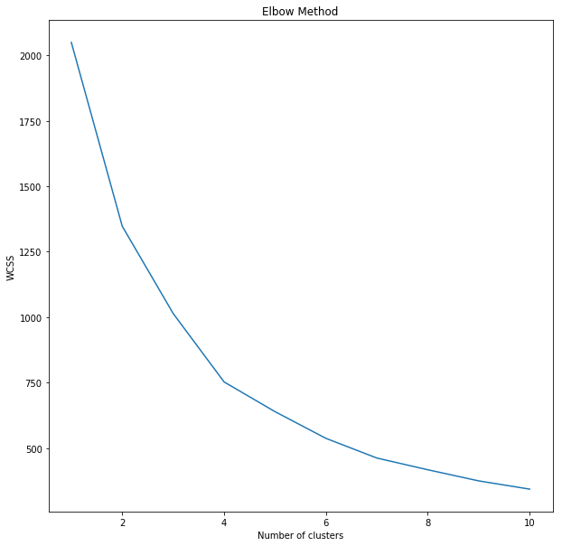

```python
plt.figure(figsize=(10,10))
wcss = []
for i in range(1, 11):
    kmeans = KMeans(n_clusters=i, init='k-means++', max_iter=300, n_init=10, random_state=0)
    kmeans.fit(for_analysis)
    wcss.append(kmeans.inertia_)
plt.plot(range(1, 11), wcss)
plt.title('Elbow Method')
plt.xlabel('Number of clusters')
plt.ylabel('WCSS')
plt.show()
```

In this case, the biggest change occurs in the 4 clusters mark, so lets run a k-mean cluster of 4 clusters on this data and see the results.

```python
kmeans = KMeans(n_clusters=4, init='k-means++', max_iter=300, n_init=10, random_state=0)
pred_y = kmeans.fit_predict(for_analysis)
for_analysis['cluster'] = pred_y
lda = LDA(n_components=2)
lda_data = lda.fit_transform(for_analysis.iloc[:,0:5].values,for_analysis.iloc[:,5].values)
new_values = pd.DataFrame(lda_data)
reduced_dimension = pd.DataFrame(new_values)
reduced_dimension['clusters'] = pd.Series(pred_y)
reduced_dimension['Provider_ID'] = list(for_analysis.index)

reduced_dimension.clusters.value_counts()
```

```
0    1741
2    1136
1     330
3      14
Name: clusters, dtype: int64
```

### LDA

In order to visualize the data in a 2D plot we need to reduce the dimensions of the datset from 5 variables to 2 variables. There are several methods used for dimension reduction and all have their pros and cons. One method I like using for clustering is LDA. The goal of LDA is to " Maximize the function that represents the difference between the means, normalized by a measure of the within-class variability" where class variability in this case is a target variable. In this case the target variable is the cluster number assigned to the observation. However, LDA has a caveat, it only performs well with normally distributed data. But since we are both normalizing and scaling the data before inputing it into the LDA model then LDA seems like the right method for this job.

Reference: LDA

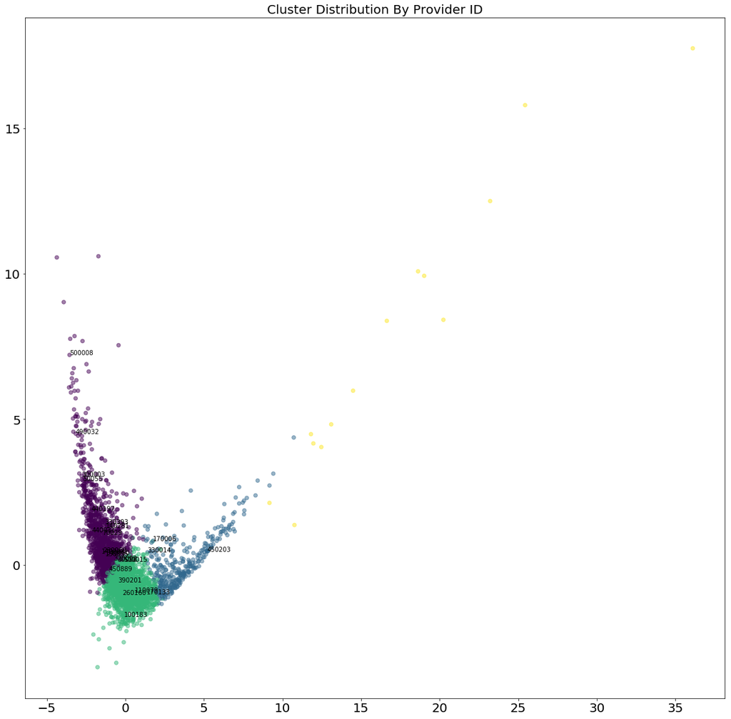

```python
plt.figure(figsize=(20,20))
x=reduced_dimension.loc[:,0]
y=reduced_dimension.loc[:,1]
plt.scatter(x,y,c=reduced_dimension['clusters'],alpha=0.5)
plt.title("Cluster Distribution By Provider ID", fontsize=20)
plt.xticks(fontsize=20)
plt.yticks(fontsize=20)

red_x = pd.DataFrame(reduced_dimension.sample(25)).reset_index()
for i in range(len(red_x)):
    fx = red_x.iloc[i,1]
    fy= red_x.iloc[i,2]
    plt.annotate(red_x.Provider_ID[i],xy=(fx,fy),size=10)
plt.show()
```

```python
#Adding our clusters to the dataset
Total_DF["Cluster_ratios"] = 0
for i in range(len(reduced_dimension)):
    Total_DF.Cluster_ratios = np.where((Total_DF["Provider Id"] == reduced_dimension['Provider_ID'][i]),reduced_dimension['clusters'][i],Total_DF.Cluster_ratios)
Total_DF.Cluster_ratios.value_counts()
```

```
0    102390
2     77876
1     25992
3      1805
Name: Cluster_ratios, dtype: int64
```

Here we can see three big clusters and a smaller cluster of what seems to be outlier observations. The K-means algo is able to do a good job here of separating the observations but there is still some overlapping going on.

### Using Z-Score to Scale the Data

It seems that the data is still very much spread out across the board. Lets look at normalizing and scaling this dataset. Becuase we are already dealing with ratios, the data is normalized. So lets move into scaling it using a z-score.

A z-score calculates the number of standard deviations that a single point is from the mean. This helps scale data while also mantaining its underlying behavior.

```python
# Create the Scaler object
scaler = StandardScaler() #the scaler function from sklearn does the z-score calculation automatically for each observation.
names = for_analysis.columns
# Fit your data on the scaler object
scaled_df = scaler.fit_transform(for_analysis)
scaled_df = pd.DataFrame(scaled_df, columns=names)
scaled_df.head()
```

[output not shown]

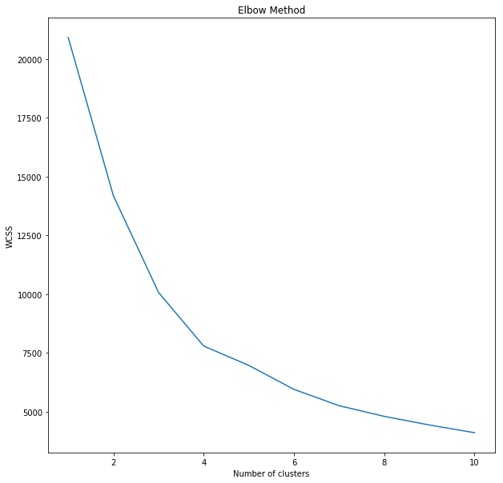

```python
plt.figure(figsize=(10,10))
wcss = []
for i in range(1, 11):
    kmeans = KMeans(n_clusters=i, init='k-means++', max_iter=300, n_init=10, random_state=0)
    kmeans.fit(scaled_df)
    wcss.append(kmeans.inertia_)
plt.plot(range(1, 11), wcss)
plt.title('Elbow Method')
plt.xlabel('Number of clusters')
plt.ylabel('WCSS')
plt.show()
```

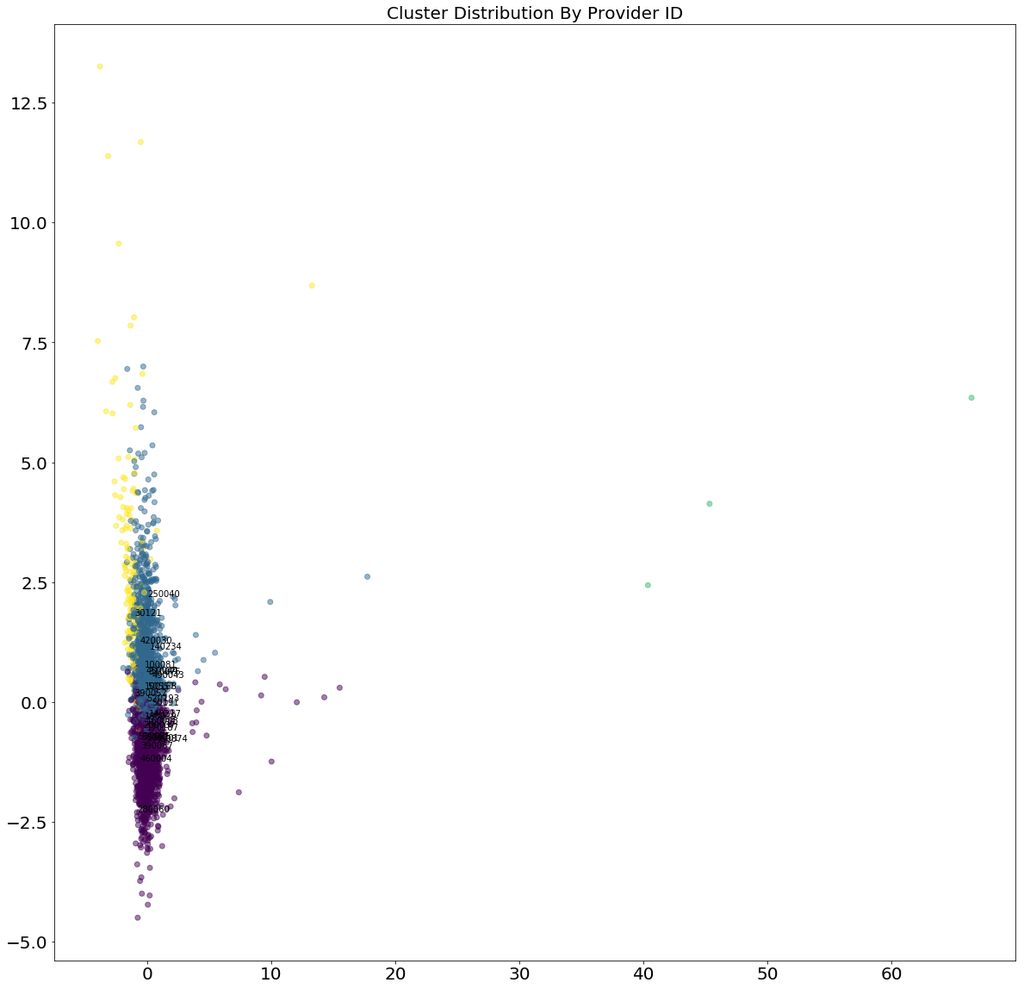

```python
kmeans = KMeans(n_clusters=4, init='k-means++', max_iter=300, n_init=10, random_state=0)
pred_y = kmeans.fit_predict(scaled_df)

scaled_df['cluster'] = pred_y
lda = LDA(n_components=2)
lda_data = lda.fit_transform(scaled_df.iloc[:,0:5].values,scaled_df.iloc[:,5].values)
new_values = pd.DataFrame(lda_data)
reduced_dimension = pd.DataFrame(new_values)
reduced_dimension['clusters'] = pd.Series(pred_y)
reduced_dimension['Provider_ID'] = list(for_analysis.index)

plt.figure(figsize=(20,20))
x=reduced_dimension.loc[:,0]
y=reduced_dimension.loc[:,1]
plt.scatter(x,y,c=reduced_dimension['clusters'],alpha=0.5)
plt.title("Cluster Distribution By Provider ID", fontsize=20)
plt.xticks(fontsize=20)
plt.yticks(fontsize=20)

red_x = pd.DataFrame(reduced_dimension.sample(25)).reset_index()
for i in range(len(red_x)):
    fx = red_x.iloc[i,1]
    fy= red_x.iloc[i,2]
    plt.annotate(red_x.Provider_ID[i],xy=(fx,fy),size=10)
plt.show()
```

```python
reduced_dimension.clusters.value_counts()
```

```
0    1731
1    1319
3     168
2       3
Name: clusters, dtype: int64
```

```python
#Adding our clusters to the dataset
Total_DF["Cluster_Scaled_ID"] = 0
for i in range(len(reduced_dimension)):
    Total_DF.Cluster_Scaled_ID = np.where((Total_DF["Provider Id"] == reduced_dimension['Provider_ID'][i]),reduced_dimension['clusters'][i],Total_DF.Cluster_Scaled_ID)
Total_DF.Cluster_Scaled_ID.value_counts()
```

```
0    100830
1     91633
3     15311
2       289
Name: Cluster_Scaled_ID, dtype: int64
```

This shows us again three very closely correlated groups and another group with observations way off the central marks. This group of outliers can be flagged as such since they are very far off representation of the entire set.

## Group By State and DRG Code

While aggregating by provider shows us great insights into the variables that seem to be outliers, looking into provider state and DRG Code can provide a bit more insight. Again the same proccess will be done where a scaled version of the aggregated data will be used to create the clusters.

```python
state_analysis = pd.DataFrame({"DRG_Def":stat_flat(Total_DF,"Provider State","ratio_Total_Discharges","DRG Definition")['DRG Definition'],
            "Total_Discharges":stat_flat(Total_DF,"Provider State","ratio_Total_Discharges","DRG Definition")['mean'],
              "Mean_Covered_Charges":stat_flat(Total_DF,"Provider State","ratio_Average_Covered_Charges","DRG Definition")['mean'],
              "Mean_Total_Payments":stat_flat(Total_DF,"Provider State","ratio_Total_Payments","DRG Definition")['mean'],
              "Mean_Medicare_Payments":stat_flat(Total_DF,"Provider State","ratio_Medicare_Payments","DRG Definition")['mean'],
              "Mean_Charge_vs_Medic":stat_flat(Total_DF,"Provider State","ratio_charge_vs_medic","DRG Definition")['mean']})


state_analysis.head(10)
```

|  | DRG_Def | Total_Discharges | Mean_Covered_Charges | Mean_Total_Payments | Mean_Medicare_Payments | Mean_Charge_vs_Medic |
| --- | --- | --- | --- | --- | --- | --- |
| AL | 001 - HEART TRANSPLANT OR IMPLANT OF HEART ASS... | 0.000092 | 1.000000 | 1.000000 | 1.000000 | 1.000000 |
| AZ | 001 - HEART TRANSPLANT OR IMPLANT OF HEART ASS... | 0.001999 | 1.210496 | 1.396619 | 1.540857 | 1.273479 |
| CA | 001 - HEART TRANSPLANT OR IMPLANT OF HEART ASS... | 0.003070 | 2.002545 | 1.764902 | 1.998240 | 1.015110 |
| CO | 001 - HEART TRANSPLANT OR IMPLANT OF HEART ASS... | 0.002681 | 1.335911 | 1.198826 | 1.220835 | 0.918505 |
| CT | 001 - HEART TRANSPLANT OR IMPLANT OF HEART ASS... | 0.002412 | 1.000000 | 1.000000 | 1.000000 | 1.000000 |
| DC | 001 - HEART TRANSPLANT OR IMPLANT OF HEART ASS... | 0.000242 | 1.000000 | 1.000000 | 1.000000 | 1.000000 |
| FL | 001 - HEART TRANSPLANT OR IMPLANT OF HEART ASS... | 0.001800 | 1.000000 | 1.000000 | 1.000000 | 1.000000 |
| GA | 001 - HEART TRANSPLANT OR IMPLANT OF HEART ASS... | 0.001015 | 1.122185 | 1.131812 | 1.278514 | 1.112513 |
| IL | 001 - HEART TRANSPLANT OR IMPLANT OF HEART ASS... | 0.002667 | 1.149616 | 1.069704 | 1.059728 | 0.967025 |
| IN | 001 - HEART TRANSPLANT OR IMPLANT OF HEART ASS... | 0.002943 | 1.269128 | 1.318250 | 1.374678 | 0.878601 |

```python
# Create the Scaler object
names = state_analysis.iloc[:,1:].columns
# Fit your data on the scaler object
scaled_state = scaler.fit_transform(state_analysis.iloc[:,1:])
scaled_state = pd.DataFrame(scaled_state, columns=names)
scaled_state.head()
```

|  | Total_Discharges | Mean_Covered_Charges | Mean_Total_Payments | Mean_Medicare_Payments | Mean_Charge_vs_Medic |
| --- | --- | --- | --- | --- | --- |
| 0 | -0.563432 | -0.137007 | -0.140229 | -0.151404 | -0.076888 |
| 1 | -0.087009 | 0.599431 | 1.373639 | 1.694817 | 1.931476 |
| 2 | 0.180429 | 3.370477 | 2.779353 | 3.256099 | 0.034078 |
| 3 | 0.083191 | 1.038206 | 0.618676 | 0.602419 | -0.675368 |
| 4 | 0.016132 | -0.137007 | -0.140229 | -0.151404 | -0.076888 |

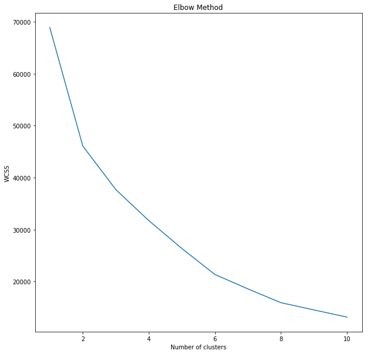

```python
plt.figure(figsize=(10,10))
wcss = []
for i in range(1, 11):
    kmeans = KMeans(n_clusters=i, init='k-means++', max_iter=300, n_init=10, random_state=0)
    kmeans.fit(scaled_state)
    wcss.append(kmeans.inertia_)
plt.plot(range(1, 11), wcss)
plt.title('Elbow Method')
plt.xlabel('Number of clusters')
plt.ylabel('WCSS')
plt.show()
```

Picking 3 clusters because it seems like the elbow bends there.

```python
kmeans = KMeans(n_clusters=3, init='k-means++', max_iter=300, n_init=10, random_state=0)
pred_y = kmeans.fit_predict(scaled_state)
scaled_state['cluster'] = pd.Series(pred_y)

lda = LDA(n_components=2)
lda_data = lda.fit_transform(scaled_state.iloc[:,0:5].values,scaled_state.iloc[:,5].values)
new_values = pd.DataFrame(lda_data)
```

```python
reduced_dimension = pd.DataFrame(new_values)
reduced_dimension['clusters'] = pd.Series(pred_y)
reduced_dimension['Provider_State'] = list(state_analysis.index)
reduced_dimension['DRG_Definition'] = list(state_analysis.iloc[:,0])
reduced_dimension.head()

reduced_dimension.clusters.value_counts()
```

```
0    12603
1      992
2        1
Name: clusters, dtype: int64
```

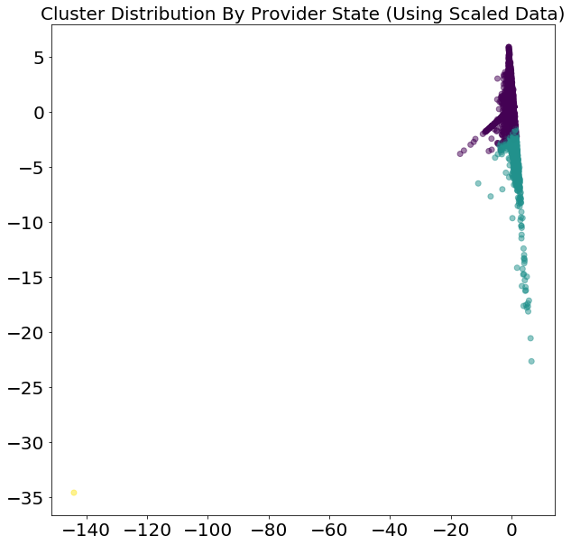

```python
plt.figure(figsize=(10,10))
x=reduced_dimension.loc[:,0]
y=reduced_dimension.loc[:,1]
plt.scatter(x,y,c=reduced_dimension['clusters'],alpha=0.5)
plt.title("Cluster Distribution By Provider State (Using Scaled Data)", fontsize=20)
plt.xticks(fontsize=20)
plt.yticks(fontsize=20)
plt.show()
```

```python
print(reduced_dimension.clusters.value_counts())
```

```
0    12603
1      992
2        1
Name: clusters, dtype: int64
```

The three clusters show again what we've been pointing out all along. Two or three big clusters with a very small outlier group. So lets flag these outliers and look at them.

```python
#Adding our clusters to the dataset
Total_DF["Cluster_PS"] = 0
for i in range(len(reduced_dimension)):
    Total_DF.Cluster_PS = np.where((Total_DF["Provider State"] == reduced_dimension['Provider_State'][i]) & (Total_DF["DRG Definition"] == reduced_dimension['DRG_Definition'][i]),reduced_dimension['clusters'][i],Total_DF.Cluster_PS)
Total_DF.Cluster_PS.value_counts()
```

```
0    194480
1     13582
2         1
Name: Cluster_PS, dtype: int64
```

```python
#Subsetting the Suspects
ind = np.where(
    (Total_DF.Cluster_PS == 2) | (Total_DF.Cluster_ratios == 3) | (Total_DF.Cluster_Scaled_ID == 2)
)
ind = list(ind[0])

suspects = Total_DF[['Provider Id','Provider State','DRG Definition',"Total Discharges","Average Covered Charges","Average Total Payments",
    "Average Medicare Payments","charge_vs_medic","RANK",'ratio_Average_Covered_Charges','ratio_Total_Payments',
         'ratio_Medicare_Payments','ratio_Total_Discharges','ratio_charge_vs_medic']].iloc[ind,:]
suspects.head()
```

|  | Provider Id | Provider State | DRG Definition | Total Discharges | Average Covered Charges | Average Total Payments | Average Medicare Payments | charge_vs_medic | RANK | ratio_Average_Covered_Charges | ratio_Total_Payments | ratio_Medicare_Payments | ratio_Total_Discharges | ratio_charge_vs_medic |
| --- | --- | --- | --- | --- | --- | --- | --- | --- | --- | --- | --- | --- | --- | --- |
| 28 | 220110 | MA | 001 - HEART TRANSPLANT OR IMPLANT OF HEART ASS... | 21 | 895376.67 | 258423.24 | 247499.05 | 27.64 | 401.0 | 1.229802 | 0.956895 | 0.957628 | 0.000078 | 0.730444 |
| 175 | 80001 | DE | 003 - ECMO OR TRACH W MV >96 HRS OR PDX EXC FA... | 64 | 277620.63 | 141846.39 | 126972.53 | 45.74 | 322.0 | 1.000000 | 1.000000 | 1.000000 | 0.000451 | 1.000000 |
| 176 | 90001 | DC | 003 - ECMO OR TRACH W MV >96 HRS OR PDX EXC FA... | 26 | 583290.46 | 144204.35 | 129197.69 | 22.15 | 275.0 | 0.882994 | 0.765871 | 0.884570 | 0.000138 | 0.991939 |
| 179 | 100001 | FL | 003 - ECMO OR TRACH W MV >96 HRS OR PDX EXC FA... | 44 | 532965.57 | 127438.07 | 117936.68 | 22.13 | 454.0 | 0.853339 | 1.094164 | 1.110060 | 0.000378 | 1.244988 |
| 196 | 100113 | FL | 003 - ECMO OR TRACH W MV >96 HRS OR PDX EXC FA... | 87 | 513206.43 | 159042.25 | 142681.63 | 27.80 | 454.0 | 0.821702 | 1.365513 | 1.342968 | 0.000747 | 1.563970 |

Lets do a visual comparison of these suspects then and see how they fare in total stats measurements.

```python
#Suspects
stat_suspect = suspects.iloc[:,9:].describe()
stat_suspect.ratio_Total_Discharges = stat_suspect.ratio_Total_Discharges*100 #multiplying by 100 to make it visible
stat_suspect
```

|  | ratio_Average_Covered_Charges | ratio_Total_Payments | ratio_Medicare_Payments | ratio_Total_Discharges | ratio_charge_vs_medic |
| --- | --- | --- | --- | --- | --- |
| count | 2095.000000 | 2095.000000 | 2095.000000 | 209500.000000 | 2095.000000 |
| mean | 1.194884 | 1.146225 | 1.148088 | 0.488826 | 1.022399 |
| std | 0.641145 | 0.468283 | 0.445055 | 0.741707 | 0.464349 |
| min | 0.094991 | 0.089888 | 0.066992 | 0.007776 | 0.178668 |
| 25% | 0.772802 | 0.908625 | 0.927484 | 0.120524 | 0.654761 |
| 50% | 1.000000 | 1.052577 | 1.057080 | 0.242515 | 1.000000 |
| 75% | 1.452266 | 1.302117 | 1.278645 | 0.529584 | 1.273271 |
| max | 5.773912 | 9.644989 | 5.102278 | 7.833541 | 4.485950 |

```python
stat_total = Total_DF[['ratio_Average_Covered_Charges','ratio_Total_Payments',
         'ratio_Medicare_Payments','ratio_Total_Discharges','ratio_charge_vs_medic']].describe()
stat_total.ratio_Total_Discharges = stat_total.ratio_Total_Discharges*100 #multiplying by 100 to make it visible
stat_total
```

|  | ratio_Average_Covered_Charges | ratio_Total_Payments | ratio_Medicare_Payments | ratio_Total_Discharges | ratio_charge_vs_medic |
| --- | --- | --- | --- | --- | --- |
| count | 208063.000000 | 208063.000000 | 208063.000000 | 2.080630e+07 | 208063.000000 |
| mean | 1.016218 | 1.013598 | 1.022234 | 4.066279e-01 | 1.015546 |
| std | 0.481714 | 0.357922 | 0.371082 | 5.481092e-01 | 0.429917 |
| min | 0.030639 | 0.034738 | 0.034197 | 4.136712e-03 | 0.039951 |
| 25% | 0.717563 | 0.846711 | 0.853117 | 1.280009e-01 | 0.746998 |
| 50% | 0.946726 | 0.957142 | 0.967831 | 2.387594e-01 | 0.959341 |
| 75% | 1.218021 | 1.123493 | 1.130462 | 4.653154e-01 | 1.188309 |
| max | 22.258397 | 18.445531 | 24.122985 | 3.689452e+01 | 12.619887 |

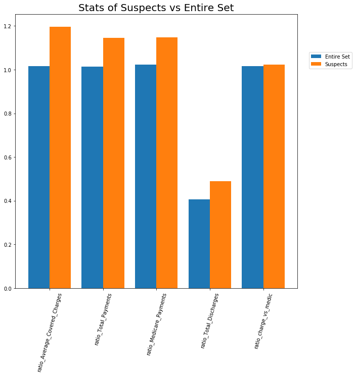

```python
plt.figure(figsize=(10,10))
x = list(stat_total.columns)
_X = np.arange(len(x))
leg = ['Entire Set','Suspects']

plt.bar(_X - 0.2, stat_total.loc['mean',:], 0.4)
plt.bar(_X + 0.2, stat_suspect.loc['mean',:], 0.4)
plt.xticks(_X, x) # set labels manually
plt.xticks(rotation=75)
plt.title('Stats of Suspects vs Entire Set',fontsize=20)
plt.legend(leg,loc=(1.04,0.8))
plt.show()
```

## Conclusion

In all three methods of k-means clustering used here I encountered a cluster that looked like an obvious outlier. Grouping these clusters together show us that in fact these observations seem to deviate away from the norm and should be flagged as outliers.